# cogsci_results

Justin Yang

May 05, 2025

# Setup

```r
# set style
condition_palette = c(
  "experience" = "#899CA5",
  "experience + hypothetical" = '#2B7CA1',
  "experience + counterfactual" = "#C04225"
  )

trial_palette = c(
    "navigation" = "#899CA5",
    "experience" = "#899CA5",
    "hypothetical" = '#2B7CA1',
    "counterfactual" = "#C04225"
  )

# only do if user if me (justyang) as its a custom font
if (Sys.info()['user'] == 'justyang') {
  font_add("AkzidenzGrotesk", "/Users/justyang/Library/Fonts/AkzidenzGroteskBE-Regular.otf")
  showtext_auto()

  theme_set(theme_classic(base_size = 14))
  theme_update(
    text = element_text(family = "AkzidenzGrotesk"),
    plot.title = element_text(family = "AkzidenzGrotesk"),
    axis.text = element_text(family = "AkzidenzGrotesk"),
    axis.title = element_text(family = "AkzidenzGrotesk"),
    legend.text = element_text(family = "AkzidenzGrotesk"),
    legend.title = element_text(family = "AkzidenzGrotesk"),
    plot.tag = element_text(family = "AkzidenzGrotesk")
  )
}
```

```r
# load data
session_df_s1 = read_csv(file.path(data_dir_s1, 'session_data.csv'))
world_df_s1 = read_csv(file.path(data_dir_s1, 'world_data.csv'))
quicksand_df_s1 = read_csv(file.path(data_dir_s1, 'trial_data.csv'))
model_df_s1 = read_csv(file.path(data_dir_s1, 'model_predictions.csv'))

session_df_s2 = read_csv(file.path(data_dir_s2, 'session_data.csv'))
world_df_s2 = read_csv(file.path(data_dir_s2, 'world_data.csv'))
quicksand_df_s2 = read_csv(file.path(data_dir_s2, 'trial_data.csv'))
model_df_s2 = read_csv(file.path(data_dir_s2, 'model_predictions.csv'))


bins = 3
day_labels = paste0("split ", 1:bins, " of ", bins)

quicksand_df_s1 <- quicksand_df_s1 %>%
  mutate(days_binned = cut_number(day, bins, labels = day_labels))
quicksand_df_s2 <- quicksand_df_s2 %>%
  mutate(days_binned = cut_number(day, bins, labels = day_labels))

quicksand_df_s1 <- quicksand_df_s1 %>%
  mutate(condition = factor(condition, levels = c("observation", "hypothetical", "counterfactual")))
quicksand_df_s2 <- quicksand_df_s2 %>%
  mutate(condition = factor(condition, levels = c("observation", "hypothetical", "counterfactual")))

quicksand_df_s2 <- quicksand_df_s2 %>%
  mutate(trial_type = recode(
    trial_type,
    "quicksand-planner" = "navigation",
    "quicksand-simulate" = "counterfactual"
  ))
```

```r
# install.packages(c("brms", "rstan", "StanHeaders"))
# install.packages(c("Rcpp", "BH"))
```

# Analysis

## Study 1 results

### Simulation path performance

**Are counterfactual paths safer than hypothetical paths?**

```r
fit.s1_manipulation_check = quicksand_df_s1 %>%
  left_join(world_df_s1 %>% select(world_id, world_spec_id), by = "world_id") %>%
  rename(environment = world_spec_id) %>%
  filter(condition %in% c('hypothetical', 'counterfactual'),
         trial_type == 'quicksand-simulate') %>%
  mutate(counterfactual = as.numeric(condition == 'counterfactual')) %>%
  brm(
    formula = hazard_count ~ 1 + counterfactual + (1 + counterfactual | game_id) + (1 | environment),
    family = poisson(),
    seed = 1,
    cores = parallel::detectCores(),
    file = 'cache/fit.s1_manipulation_check'
  )

summary(fit.s1_manipulation_check)
```

```
##  Family: poisson
##   Links: mu = log
## Formula: hazard_count ~ 1 + counterfactual + (1 + counterfactual | game_id) + (1 | environment)
##    Data: . (Number of observations: 2640)
##   Draws: 4 chains, each with iter = 2000; warmup = 1000; thin = 1;
##          total post-warmup draws = 4000
##
## Multilevel Hyperparameters:
## ~environment (Number of levels: 4)
##               Estimate Est.Error l-95% CI u-95% CI Rhat Bulk_ESS Tail_ESS
## sd(Intercept)     0.47      0.27     0.18     1.18 1.00     1207     1763
##
## ~game_id (Number of levels: 44)
##                               Estimate Est.Error l-95% CI u-95% CI Rhat
## sd(Intercept)                     0.02      0.01     0.00     0.05 1.00
## sd(counterfactual)                0.04      0.03     0.00     0.09 1.00
## cor(Intercept,counterfactual)    -0.10      0.58    -0.96     0.94 1.00
##                               Bulk_ESS Tail_ESS
## sd(Intercept)                     2055     2081
## sd(counterfactual)                1464     1849
## cor(Intercept,counterfactual)     2440     2618
##
## Regression Coefficients:
##                Estimate Est.Error l-95% CI u-95% CI Rhat Bulk_ESS Tail_ESS
## Intercept          1.20      0.24     0.70     1.72 1.00     1297     1450
## counterfactual    -0.18      0.02    -0.22    -0.13 1.00     4983     2593
##
## Draws were sampled using sampling(NUTS). For each parameter, Bulk_ESS
## and Tail_ESS are effective sample size measures, and Rhat is the potential
## scale reduction factor on split chains (at convergence, Rhat = 1).
```

```r
fit.s1_manipulation_check %>%
  emmeans(specs=pairwise~counterfactual)
```

```
## $emmeans
##  counterfactual emmean lower.HPD upper.HPD
##               0   1.20     0.738      1.74
##               1   1.02     0.573      1.57
##
## Point estimate displayed: median
## Results are given on the log (not the response) scale.
## HPD interval probability: 0.95
##
## $contrasts
##  contrast                          estimate lower.HPD upper.HPD
##  counterfactual0 - counterfactual1    0.178     0.129     0.225
##
## Point estimate displayed: median
## Results are given on the log (not the response) scale.
## HPD interval probability: 0.95
```

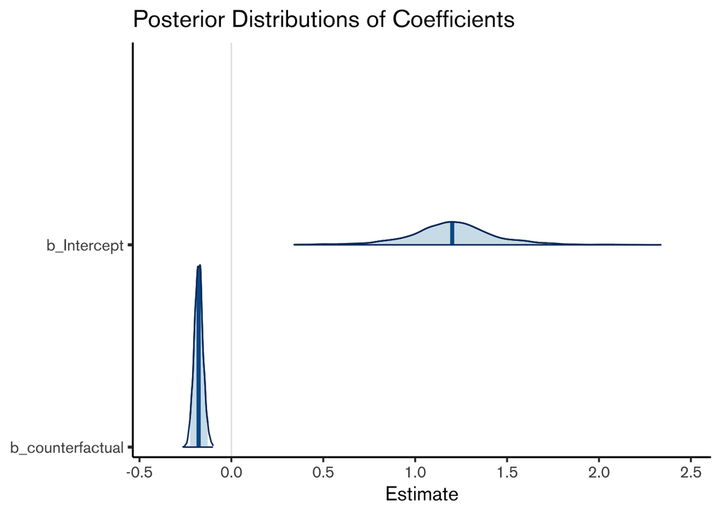

```r
posterior <- as_draws_df(fit.s1_manipulation_check)
mcmc_areas(posterior,
           pars = c("b_Intercept", "b_counterfactual"),
           prob = 0.95) +  # Show 95% credible intervals
  ggtitle("Posterior Distributions of Coefficients") +
  xlab("Estimate")
```

### Hypothesis 1: Counterfactual simulation produces safer paths than the other conditions

```r
fit.s1_hypothesis1 = quicksand_df_s1 %>%
  left_join(world_df_s1 %>% select(world_id, world_spec_id), by = "world_id") %>%
  rename(environment = world_spec_id) %>%
  filter(trial_type == 'quicksand-planner') %>%
  mutate(condition = factor(condition, levels = c("observation", "hypothetical", "counterfactual"))) %>%
  brm(
    formula = hazard_count ~ 1 + condition * day + (1 + day | game_id) + (1 | environment),
    family = poisson(),
    seed = 1,
    chains = 8,
    iter = 4000,
    cores = parallel::detectCores(),
    file = 'cache/fit.s1_hypothesis1'
  )

summary(fit.s1_hypothesis1)
```

```
##  Family: poisson
##   Links: mu = log
## Formula: hazard_count ~ 1 + condition * day + (1 + day | game_id) + (1 | environment)
##    Data: . (Number of observations: 3600)
##   Draws: 8 chains, each with iter = 4000; warmup = 2000; thin = 1;
##          total post-warmup draws = 16000
##
## Multilevel Hyperparameters:
## ~environment (Number of levels: 4)
##               Estimate Est.Error l-95% CI u-95% CI Rhat Bulk_ESS Tail_ESS
## sd(Intercept)     0.28      0.17     0.09     0.72 1.02      345      549
##
## ~game_id (Number of levels: 60)
##                    Estimate Est.Error l-95% CI u-95% CI Rhat Bulk_ESS Tail_ESS
## sd(Intercept)          0.02      0.02     0.00     0.06 1.01     2158     5414
## sd(day)                0.01      0.00     0.00     0.01 1.01     1165     2270
## cor(Intercept,day)     0.22      0.50    -0.84     0.96 1.02      761     1327
##
## Regression Coefficients:
##                             Estimate Est.Error l-95% CI u-95% CI Rhat Bulk_ESS
## Intercept                       1.63      0.17     1.14     1.96 1.03      179
## conditionhypothetical           0.00      0.04    -0.07     0.08 1.01      800
## conditioncounterfactual        -0.05      0.04    -0.13     0.02 1.00     8546
## day                            -0.02      0.00    -0.02    -0.01 1.01     2489
## conditionhypothetical:day       0.01      0.00    -0.00     0.02 1.01     1406
## conditioncounterfactual:day     0.01      0.01    -0.00     0.02 1.01     7485
##                             Tail_ESS
## Intercept                         36
## conditionhypothetical            948
## conditioncounterfactual        10341
## day                             9707
## conditionhypothetical:day       9717
## conditioncounterfactual:day     9455
##
## Draws were sampled using sampling(NUTS). For each parameter, Bulk_ESS
## and Tail_ESS are effective sample size measures, and Rhat is the potential
## scale reduction factor on split chains (at convergence, Rhat = 1).
```

```r
fit.s1_hypothesis1 %>% # in non-log scale
  emmeans(specs = pairwise~condition)
```

```
## $emmeans
##  condition      emmean lower.HPD upper.HPD
##  observation      1.53     0.979      1.78
##  hypothetical     1.57     0.999      1.81
##  counterfactual   1.54     0.972      1.78
##
## Point estimate displayed: median
## Results are given on the log (not the response) scale.
## HPD interval probability: 0.95
##
## $contrasts
##  contrast                      estimate lower.HPD upper.HPD
##  observation - hypothetical    -0.04368   -0.0991   0.00482
##  observation - counterfactual  -0.00993   -0.0662   0.04326
##  hypothetical - counterfactual  0.03378   -0.0150   0.08340
##
## Point estimate displayed: median
## Results are given on the log (not the response) scale.
## HPD interval probability: 0.95
```

```r
fit.s1_hypothesis1 %>% # in non-log scale
  emtrends(specs = pairwise~condition, var = "day")
```

```
## $emtrends
##  condition      day.trend lower.HPD upper.HPD
##  observation     -0.01664   -0.0236  -0.00853
##  hypothetical    -0.01087   -0.0173  -0.00482
##  counterfactual  -0.00769   -0.0145  -0.00111
##
## Point estimate displayed: median
## HPD interval probability: 0.95
##
## $contrasts
##  contrast                      estimate lower.HPD upper.HPD
##  observation - hypothetical    -0.00572   -0.0149  0.004384
##  observation - counterfactual  -0.00897   -0.0192  0.000925
##  hypothetical - counterfactual -0.00310   -0.0122  0.005594
##
## Point estimate displayed: median
## HPD interval probability: 0.95
```

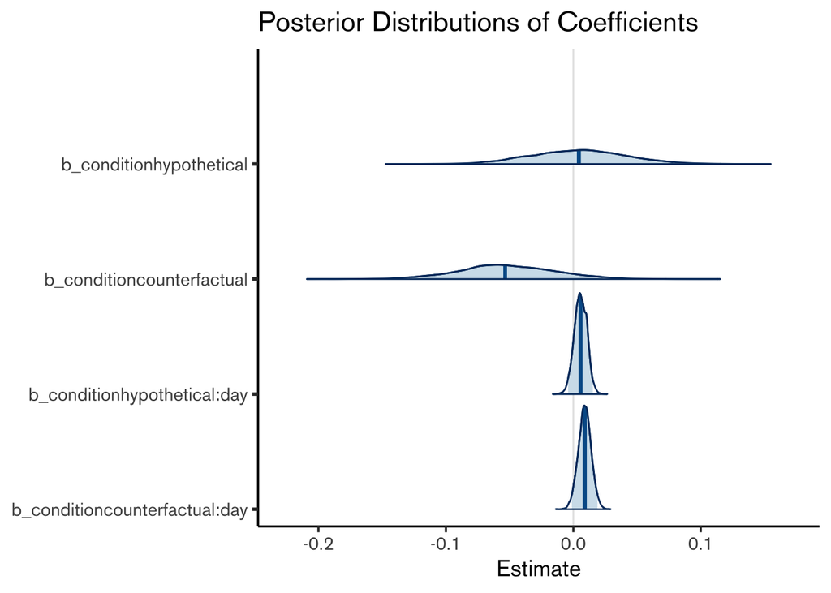

```r
posterior <- as_draws_df(fit.s1_hypothesis1)
mcmc_areas(posterior,
           regex_pars = "b_condition",
           prob = 0.95) +  # Show 95% credible intervals
  ggtitle("Posterior Distributions of Coefficients") +
  xlab("Estimate")
```

### Counterfactual vs. Hypothetical condition

```r
fit.s1_hypothetical = quicksand_df_s1 %>%
  left_join(world_df_s1 %>% select(world_id, world_spec_id), by = "world_id") %>%
  rename(environment = world_spec_id) %>%
  filter(
    (trial_type == 'quicksand-planner') & (condition %in% c("hypothetical", "counterfactual"))) %>%
  mutate(condition = factor(condition, levels = c("hypothetical", "counterfactual"))) %>%
  brm(
    formula = hazard_count ~ 1 + condition * day + (1 + day | game_id) + (1 | environment),
    family = poisson(),
    seed = 1,
    chains = 8,
    iter = 4000,
    cores = parallel::detectCores(),
    file = 'cache/fit.s1_hypothetical'
  )

summary(fit.s1_hypothetical)
```

```
##  Family: poisson
##   Links: mu = log
## Formula: hazard_count ~ 1 + condition * day + (1 + day | game_id) + (1 | environment)
##    Data: . (Number of observations: 2640)
##   Draws: 8 chains, each with iter = 4000; warmup = 2000; thin = 1;
##          total post-warmup draws = 16000
##
## Multilevel Hyperparameters:
## ~environment (Number of levels: 4)
##               Estimate Est.Error l-95% CI u-95% CI Rhat Bulk_ESS Tail_ESS
## sd(Intercept)     0.27      0.19     0.09     0.81 1.01     1443      470
##
## ~game_id (Number of levels: 44)
##                    Estimate Est.Error l-95% CI u-95% CI Rhat Bulk_ESS Tail_ESS
## sd(Intercept)          0.03      0.02     0.00     0.07 1.00     2062     4347
## sd(day)                0.01      0.00     0.00     0.01 1.00     1089     2495
## cor(Intercept,day)     0.20      0.53    -0.88     0.97 1.00      656     1015
##
## Regression Coefficients:
##                             Estimate Est.Error l-95% CI u-95% CI Rhat Bulk_ESS
## Intercept                       1.65      0.16     1.27     1.97 1.01     1286
## conditioncounterfactual        -0.06      0.03    -0.13     0.01 1.00     8462
## day                            -0.01      0.00    -0.02    -0.00 1.00     9551
## conditioncounterfactual:day     0.00      0.00    -0.01     0.01 1.00     7822
##                             Tail_ESS
## Intercept                        452
## conditioncounterfactual        11414
## day                            10424
## conditioncounterfactual:day     9283
##
## Draws were sampled using sampling(NUTS). For each parameter, Bulk_ESS
## and Tail_ESS are effective sample size measures, and Rhat is the potential
## scale reduction factor on split chains (at convergence, Rhat = 1).
```

```r
fit.s1_hypothetical %>%
  emmeans(specs = pairwise~condition)
```

```
## $emmeans
##  condition      emmean lower.HPD upper.HPD
##  hypothetical     1.57      1.23      1.91
##  counterfactual   1.54      1.19      1.87
##
## Point estimate displayed: median
## Results are given on the log (not the response) scale.
## HPD interval probability: 0.95
##
## $contrasts
##  contrast                      estimate lower.HPD upper.HPD
##  hypothetical - counterfactual   0.0338   -0.0208    0.0854
##
## Point estimate displayed: median
## Results are given on the log (not the response) scale.
## HPD interval probability: 0.95
```

```r
fit.s1_hypothetical %>%
  emtrends(specs = pairwise~condition, var = "day")
```

```
## $emtrends
##  condition      day.trend lower.HPD upper.HPD
##  hypothetical    -0.01104   -0.0176 -0.005141
##  counterfactual  -0.00759   -0.0146 -0.000805
##
## Point estimate displayed: median
## HPD interval probability: 0.95
##
## $contrasts
##  contrast                      estimate lower.HPD upper.HPD
##  hypothetical - counterfactual -0.00347   -0.0129   0.00571
##
## Point estimate displayed: median
## HPD interval probability: 0.95
```

## Study 2 results

We follow the analysis plan outlined in the preregistration: https://osf.io/tzha7.

### Manipulation checks

**Do people understand what to do when simulating counterfactuals?**

In counterfactual simulation trials, participants make paths from start to goal, conditioning on the outcome of their previous experience. With the task of improving on their previous plan, we should expect that participants’ counterfactual paths should at minimum be as good as their previous path, as that would simply amount to retracing their previous steps. So we test participants’ understanding or engagement of the counterfactual trials by first asking if participants’ counterfactual paths outperform their actual paths by fitting a Bayesian mixed-effects model on the number of unsafe tiles in a path between matched actual and counterfactual paths:

```
hazard_count ~ 1 + counterfactual + (1 + counterfactual | participant) + (1 | environment)
```

```r
fit.s2_manipulation_check = quicksand_df_s2 %>%
  left_join(world_df_s2 %>% select(world_id, world_spec_id), by = "world_id") %>%
  rename(environment = world_spec_id) %>%
  filter(condition == 'counterfactual') %>%
  mutate(counterfactual = as.numeric(trial_type == 'counterfactual')) %>%
  brm(
    formula = hazard_count ~ 1 + counterfactual + (1 + counterfactual | game_id) + (1 | environment),
    family = poisson(),
    seed = 1,
    cores = parallel::detectCores(),
    file = 'cache/fit.s2_manipulation_check'
  )

summary(fit.s2_manipulation_check)
```

```
##  Family: poisson
##   Links: mu = log
## Formula: hazard_count ~ 1 + counterfactual + (1 + counterfactual | game_id) + (1 | environment)
##    Data: . (Number of observations: 3060)
##   Draws: 4 chains, each with iter = 2000; warmup = 1000; thin = 1;
##          total post-warmup draws = 4000
##
## Multilevel Hyperparameters:
## ~environment (Number of levels: 2)
##               Estimate Est.Error l-95% CI u-95% CI Rhat Bulk_ESS Tail_ESS
## sd(Intercept)     1.20      1.38     0.13     4.56 1.33       10       12
##
## ~game_id (Number of levels: 51)
##                               Estimate Est.Error l-95% CI u-95% CI Rhat
## sd(Intercept)                     0.06      0.02     0.02     0.09 1.26
## sd(counterfactual)                0.02      0.02     0.00     0.05 1.12
## cor(Intercept,counterfactual)    -0.16      0.58    -0.98     0.90 1.07
##                               Bulk_ESS Tail_ESS
## sd(Intercept)                      803      650
## sd(counterfactual)                  22     1864
## cor(Intercept,counterfactual)       38     1694
##
## Regression Coefficients:
##                Estimate Est.Error l-95% CI u-95% CI Rhat Bulk_ESS Tail_ESS
## Intercept          1.46      0.40     0.51     2.30 1.04     1127      590
## counterfactual    -0.14      0.02    -0.17    -0.10 1.05       49     2330
##
## Draws were sampled using sampling(NUTS). For each parameter, Bulk_ESS
## and Tail_ESS are effective sample size measures, and Rhat is the potential
## scale reduction factor on split chains (at convergence, Rhat = 1).
```

```r
fit.s2_manipulation_check %>%
  emmeans(specs=pairwise~counterfactual)
```

```
## $emmeans
##  counterfactual emmean lower.HPD upper.HPD
##               0   1.49     0.601      2.36
##               1   1.35     0.426      2.18
##
## Point estimate displayed: median
## Results are given on the log (not the response) scale.
## HPD interval probability: 0.95
##
## $contrasts
##  contrast                          estimate lower.HPD upper.HPD
##  counterfactual0 - counterfactual1    0.134     0.103     0.171
##
## Point estimate displayed: median
## Results are given on the log (not the response) scale.
## HPD interval probability: 0.95
```

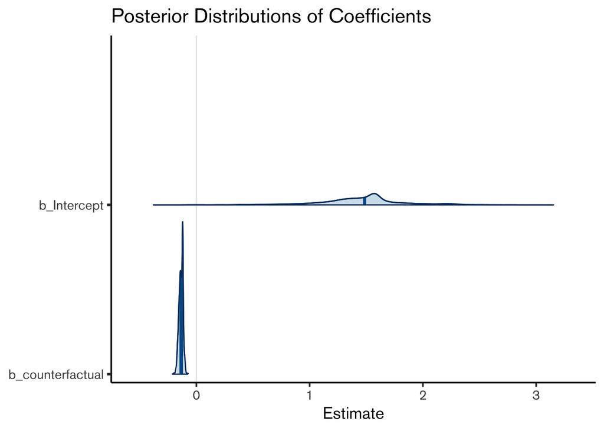

```r
posterior <- as_draws_df(fit.s2_manipulation_check)
mcmc_areas(posterior,
           pars = c("b_Intercept", "b_counterfactual"),
           prob = 0.95) +  # Show 95% credible intervals
  ggtitle("Posterior Distributions of Coefficients") +
  xlab("Estimate")
```

### Hypothesis 1: Counterfactual simulation produces safer paths

Does engaging in counterfactual simulation result in fewer encounters with hazards when navigating a gridworld environment? Our analysis will consist of understanding whether participants assigned to the counterfactual condition encounter fewer hazards on navigation trials, for which we use the following Bayesian mixed-effects model structure (using a Poisson distribution):

```r
fit.s2_hypothesis1 = quicksand_df_s2 %>%
  left_join(world_df_s2 %>% select(world_id, world_spec_id), by = "world_id") %>%
  rename(environment = world_spec_id) %>%
  filter(trial_type == 'navigation') %>%
  mutate(condition = ifelse(condition == "counterfactual", 1, -1),) %>%
  brm(
    formula = hazard_count ~ 1 + condition * day + (1 + day | game_id) + (1 | environment),
    family = poisson(),
    seed = 1,
    chains = 8,
    iter = 4000,
    cores = parallel::detectCores(),
    file = 'cache/fit.s2_hypothesis1'
  )

summary(fit.s2_hypothesis1)
```

```
##  Family: poisson
##   Links: mu = log
## Formula: hazard_count ~ 1 + condition * day + (1 + day | game_id) + (1 | environment)
##    Data: . (Number of observations: 3030)
##   Draws: 8 chains, each with iter = 4000; warmup = 2000; thin = 1;
##          total post-warmup draws = 16000
##
## Multilevel Hyperparameters:
## ~environment (Number of levels: 2)
##               Estimate Est.Error l-95% CI u-95% CI Rhat Bulk_ESS Tail_ESS
## sd(Intercept)     0.88      0.74     0.10     2.53 1.13       40      107
##
## ~game_id (Number of levels: 101)
##                    Estimate Est.Error l-95% CI u-95% CI Rhat Bulk_ESS Tail_ESS
## sd(Intercept)          0.04      0.02     0.00     0.08 1.04      772     2005
## sd(day)                0.01      0.00     0.00     0.01 1.03      281     2531
## cor(Intercept,day)     0.38      0.50    -0.77     0.98 1.18       30       28
##
## Regression Coefficients:
##               Estimate Est.Error l-95% CI u-95% CI Rhat Bulk_ESS Tail_ESS
## Intercept         1.59      0.59     0.38     2.62 1.15       35      182
## condition         0.01      0.02    -0.03     0.05 1.21       26       24
## day              -0.01      0.00    -0.01    -0.00 1.05     1782     4968
## condition:day    -0.00      0.00    -0.01     0.00 1.21       26       32
##
## Draws were sampled using sampling(NUTS). For each parameter, Bulk_ESS
## and Tail_ESS are effective sample size measures, and Rhat is the potential
## scale reduction factor on split chains (at convergence, Rhat = 1).
```

```r
fit.s2_hypothesis1 %>%
  emmeans(specs=pairwise~condition)
```

```
## $emmeans
##  condition emmean lower.HPD upper.HPD
##         -1   1.45      0.33      2.57
##          1   1.46      0.34      2.58
##
## Point estimate displayed: median
## Results are given on the log (not the response) scale.
## HPD interval probability: 0.95
##
## $contrasts
##  contrast                   estimate lower.HPD upper.HPD
##  (condition-1) - condition1 -0.00808   -0.0486    0.0338
##
## Point estimate displayed: median
## Results are given on the log (not the response) scale.
## HPD interval probability: 0.95
```

```r
fit.s2_hypothesis1 %>%
  emtrends(specs = pairwise~condition, var = "day")
```

```
## $emtrends
##  condition day.trend lower.HPD upper.HPD
##         -1  -0.00821   -0.0139  -0.00188
##          1  -0.00857   -0.0142  -0.00260
##
## Point estimate displayed: median
## HPD interval probability: 0.95
##
## $contrasts
##  contrast                   estimate lower.HPD upper.HPD
##  (condition-1) - condition1 8.55e-05   -0.0077    0.0108
##
## Point estimate displayed: median
## HPD interval probability: 0.95
```

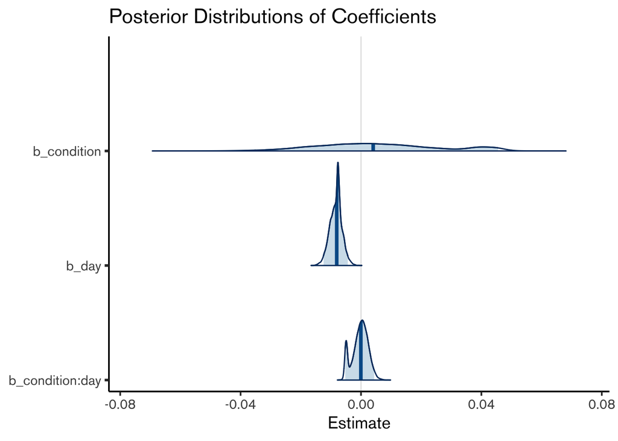

```r
posterior <- as_draws_df(fit.s2_hypothesis1)
mcmc_areas(posterior,
           pars = c("b_condition", "b_day", "b_condition:day"),
           prob = 0.95) +  # Show 95% credible intervals
  ggtitle("Posterior Distributions of Coefficients") +
  xlab("Estimate")
```

### Hypothesis 2: Counterfactual simulation produces a more accurate mental model of the environment

Our primary analysis in this experiment focuses on whether participants’ ability to reason counterfactually could result in a greater understanding of their environment. We operationalize this notion of understanding in an exam trial where participants mark which tiles they think are safe or unsafe in their gridworld environment.

#### Hypothesis 2a: Exam accuracy

We compare the accuracies of the responses in the exam trials across the observation and counterfactual conditions. We predict that responses in the counterfactual condition will be more accurate than those in the observational condition.

```r
fit.s2_hypothesis2a = world_df_s2 %>%
  rename(environment = world_spec_id) %>%
  mutate(condition = ifelse(condition == "counterfactual", 1, -1)) %>%
  brm(
    formula = exam_trial_correct_tiles ~ 1 + condition + (1 | game_id) + (1 | environment),
    seed = 1,
    chains = 8,
    iter = 4000,
    cores = parallel::detectCores(),
    file = 'cache/fit.s2_hypothesis2a'
  )

summary(fit.s2_hypothesis2a)
```

```
##  Family: gaussian
##   Links: mu = identity; sigma = identity
## Formula: exam_trial_correct_tiles ~ 1 + condition + (1 | game_id) + (1 | environment)
##    Data: . (Number of observations: 202)
##   Draws: 8 chains, each with iter = 4000; warmup = 2000; thin = 1;
##          total post-warmup draws = 16000
##
## Multilevel Hyperparameters:
## ~environment (Number of levels: 2)
##               Estimate Est.Error l-95% CI u-95% CI Rhat Bulk_ESS Tail_ESS
## sd(Intercept)     1.92      1.68     0.20     6.50 1.01     1037      412
##
## ~game_id (Number of levels: 101)
##               Estimate Est.Error l-95% CI u-95% CI Rhat Bulk_ESS Tail_ESS
## sd(Intercept)     2.57      0.30     1.99     3.18 1.00     3363     7474
##
## Regression Coefficients:
##           Estimate Est.Error l-95% CI u-95% CI Rhat Bulk_ESS Tail_ESS
## Intercept    15.52      1.33    12.62    18.66 1.01     1149      532
## condition    -0.11      0.31    -0.72     0.50 1.00     4265     6991
##
## Further Distributional Parameters:
##       Estimate Est.Error l-95% CI u-95% CI Rhat Bulk_ESS Tail_ESS
## sigma     2.67      0.19     2.32     3.06 1.00     4270     4621
##
## Draws were sampled using sampling(NUTS). For each parameter, Bulk_ESS
## and Tail_ESS are effective sample size measures, and Rhat is the potential
## scale reduction factor on split chains (at convergence, Rhat = 1).
```

```r
fit.s2_hypothesis2a %>%
  emmeans(specs=pairwise~condition)
```

```
## $emmeans
##  condition emmean lower.HPD upper.HPD
##         -1   15.6      12.9      18.8
##          1   15.4      12.6      18.4
##
## Point estimate displayed: median
## HPD interval probability: 0.95
##
## $contrasts
##  contrast                   estimate lower.HPD upper.HPD
##  (condition-1) - condition1    0.225    -0.975      1.45
##
## Point estimate displayed: median
## HPD interval probability: 0.95
```

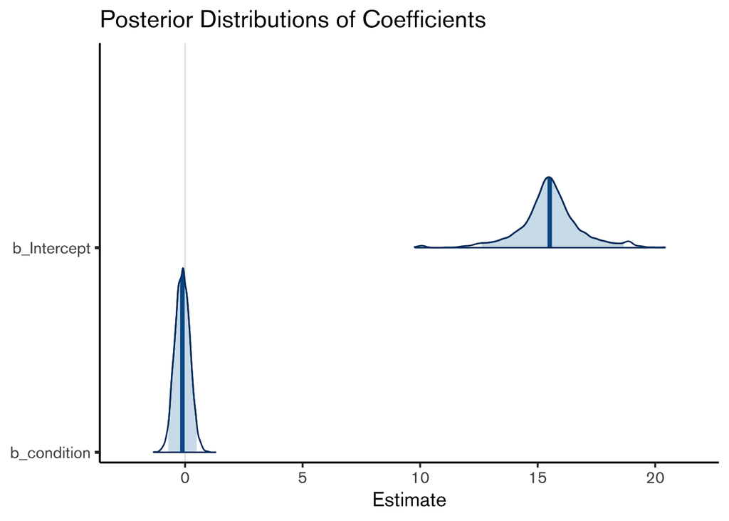

```r
posterior <- as_draws_df(fit.s2_hypothesis2a)
mcmc_areas(posterior,
           pars = c("b_Intercept", "b_condition"),
           prob = 0.95) +  # Show 95% credible intervals
  ggtitle("Posterior Distributions of Coefficients") +
  xlab("Estimate")
```

#### Hypothesis 2b: Exam path safety

It may be possible that participants in the counterfactual condition learn a more accurate model of the environment particularly where it matters. So we also predict that rational planning under beliefs obtained in the counterfactual condition will result in encountering fewer hazards than those obtained in the observation condition.

```r
fit.s2_hypothesis2b = world_df_s2 %>%
  rename(environment = world_spec_id) %>%
  mutate(condition = ifelse(condition == "counterfactual", 1, -1)) %>%
  brm(
    formula = exam_trial_hazard_count ~ 1 + condition + (1 | game_id) + (1 | environment),
    family = Gamma(link = "log"),
    seed = 1,
    chains = 8,
    iter = 4000,
    cores = parallel::detectCores(),
    file = 'cache/fit.s2_hypothesis2b',
  )

summary(fit.s2_hypothesis2b)
```

```
##  Family: gamma
##   Links: mu = log; shape = identity
## Formula: exam_trial_hazard_count ~ 1 + condition + (1 | game_id) + (1 | environment)
##    Data: . (Number of observations: 202)
##   Draws: 8 chains, each with iter = 4000; warmup = 2000; thin = 1;
##          total post-warmup draws = 16000
##
## Multilevel Hyperparameters:
## ~environment (Number of levels: 2)
##               Estimate Est.Error l-95% CI u-95% CI Rhat Bulk_ESS Tail_ESS
## sd(Intercept)     0.31      0.44     0.01     1.61 1.02      537      165
##
## ~game_id (Number of levels: 101)
##               Estimate Est.Error l-95% CI u-95% CI Rhat Bulk_ESS Tail_ESS
## sd(Intercept)     0.17      0.05     0.04     0.26 1.01     1181     1098
##
## Regression Coefficients:
##           Estimate Est.Error l-95% CI u-95% CI Rhat Bulk_ESS Tail_ESS
## Intercept     1.20      0.22     0.80     1.62 1.02     1436      389
## condition     0.03      0.03    -0.03     0.08 1.00     3424     1701
##
## Further Distributional Parameters:
##       Estimate Est.Error l-95% CI u-95% CI Rhat Bulk_ESS Tail_ESS
## shape     9.47      1.40     6.96    12.33 1.01     1592     1638
##
## Draws were sampled using sampling(NUTS). For each parameter, Bulk_ESS
## and Tail_ESS are effective sample size measures, and Rhat is the potential
## scale reduction factor on split chains (at convergence, Rhat = 1).
```

```r
fit.s2_hypothesis2b %>%
  emmeans(specs=pairwise~condition)
```

```
## $emmeans
##  condition emmean lower.HPD upper.HPD
##         -1   1.17     0.764      1.58
##          1   1.22     0.841      1.67
##
## Point estimate displayed: median
## Results are given on the log (not the response) scale.
## HPD interval probability: 0.95
##
## $contrasts
##  contrast                   estimate lower.HPD upper.HPD
##  (condition-1) - condition1  -0.0503    -0.167    0.0688
##
## Point estimate displayed: median
## Results are given on the log (not the response) scale.
## HPD interval probability: 0.95
```

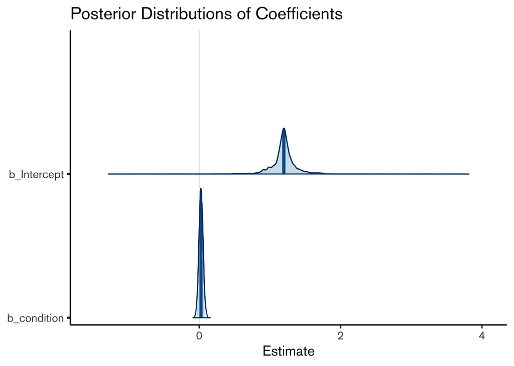

```r
posterior <- as_draws_df(fit.s2_hypothesis2b)
mcmc_areas(posterior,
           pars = c("b_Intercept", "b_condition"),
           prob = 0.95) +  # Show 95% credible intervals
  ggtitle("Posterior Distributions of Coefficients") +
  xlab("Estimate")
```

# Plots

```r
recode_labels <- c("observation" = "experience",
                   "hypothetical" = "experience + hypothetical",
                   "counterfactual" = "experience + counterfactual")

condition_labels <- c("experience" = "experience",
                      "experience + hypothetical" = "hypothetical",
                      "experience + counterfactual" = "counterfactual")

condition_legend_labels <- c("experience" = "experience",
                             "experience + hypothetical" = "+ hypothetical",
                             "experience + counterfactual" = "+ counterfactual")

day_split_labels <- c("split 1 of 3" = "split 1",
                      "split 2 of 3" = "split 2",
                      "split 3 of 3" = "split 3")

quicksand_df_s1 <- quicksand_df_s1 %>%
  mutate(condition = recode(condition, !!!recode_labels))
  # mutate(condition = recode(condition, !!!as.list(condition_labels)))

quicksand_df_s2 <- quicksand_df_s2 %>%
  mutate(condition = recode(condition, !!!recode_labels))

world_df_s2 <- world_df_s2 %>%
  mutate(condition = recode(condition, !!!recode_labels))
```

## Manipulation check: Simulated paths

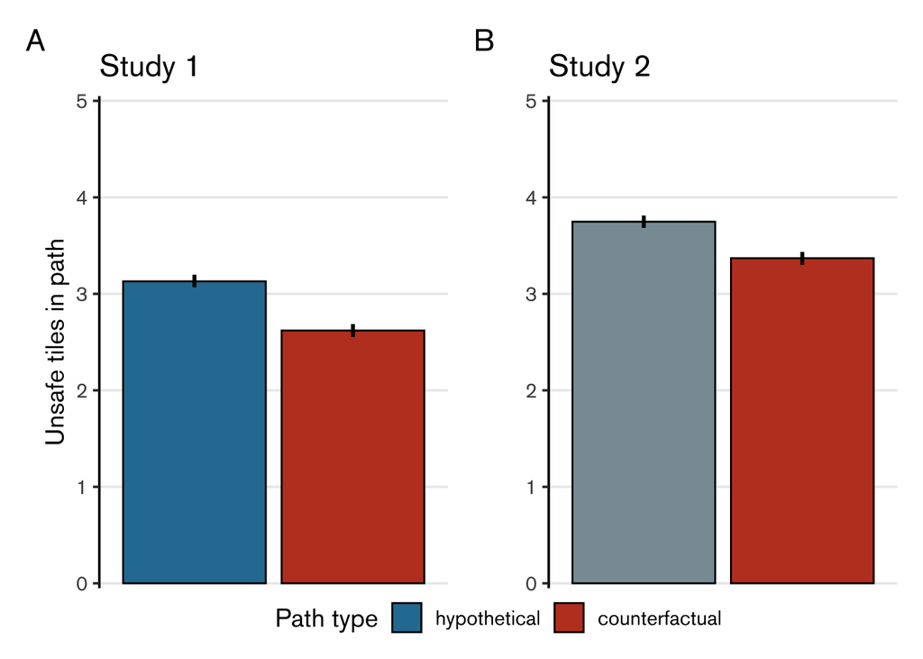

```r
path_type_levels <- c("experience", "hypothetical", "counterfactual")

# Pilot Study: Manipulation Check
fig_s1_manipulation <- quicksand_df_s1 %>%
  filter(trial_type == "quicksand-simulate") %>%
  mutate(path_type = case_when(
      trial_type == "quicksand-simulate" & condition == "experience + hypothetical" ~ "hypothetical",
      trial_type == "quicksand-simulate" & condition == "experience + counterfactual" ~ "counterfactual",
      TRUE ~ "experience" # Force experience level
    ),
    path_type = factor(path_type, levels = path_type_levels)
  ) %>%
  ggplot(aes(x = path_type,
             y = hazard_count,
             fill = path_type)) +
  stat_summary(fun = mean,
               geom = "bar",
               color = "black") +
  stat_summary(fun.data = mean_cl_boot,
               geom = "linerange",
               size = 1,
               width = 0.2) +
  scale_fill_manual(values = trial_palette) +
  scale_y_continuous(breaks = seq(0, 5, 1),
                     limit = c(0, 5),
                     expand = expansion(mult = 0.01)) +
  labs(title = "Study 1",
       x = "Path type",
       y = "Unsafe tiles in path",
       fill = "Path type")

# Full Study: Manipulation Check
fig_s2_manipulation <- quicksand_df_s2 %>%
  filter(condition == "experience + counterfactual") %>%
  mutate(trial_type = recode(trial_type, "navigation" = "experience")) %>%
  mutate(path_type = factor(trial_type, levels = path_type_levels)) %>%
  ggplot(aes(x = path_type,
             y = hazard_count,
             fill = path_type)) +
  stat_summary(fun = mean,
               geom = "bar",
               color = "black") +
  stat_summary(fun.data = mean_cl_boot,
               geom = "linerange",
               size = 1,
               width = 0.2) +
  scale_fill_manual(values = trial_palette,
                    breaks = path_type_levels,
                    drop = FALSE) +
  scale_y_continuous(breaks = seq(0, 5, 1),
                     limit = c(0, 5),
                     expand = expansion(mult = 0.01)) +
  labs(title = "Study 2",
       y = " ",
       x = "Trial type",
       fill = "Path type") +
  guides(fill = "none")

legend_plot <- ggplot(data.frame(path_type = path_type_levels),
                      aes(x = path_type, fill = path_type)) +
  geom_bar() +  # Dummy plot to create legend
  scale_fill_manual(values = trial_palette, name = "Path type") +
  theme_minimal() +
  theme(legend.position = "bottom")

# Combine Plots in One Row
fig_combined_manipulation <- fig_s1_manipulation + fig_s2_manipulation +
  plot_layout(ncol = 2, guides = "collect") &
  plot_annotation(tag_levels = "A") & # uses plot.tag
  theme(axis.title.x = element_blank(),
        axis.text.x = element_blank(),
        axis.line.x = element_blank(),
        axis.ticks.x = element_blank(),
        panel.grid.major.y = element_line(),
        legend.position = "bottom",
        legend.margin = margin(-10, 0, 0, 0))

ggsave(file.path(figures_dir, "manipulation_check.pdf"), width = 7, height = 3, useDingbats = FALSE)

fig_combined_manipulation
```

## Hypothesis 1: Navigation performance

```r
quicksand_df_s1 %>%
  filter(world_id == '2139-5c7ee136-9214-458c-85c0-388bc9cb44da')
```

[output not shown]

[output cut: 5 more lines]

```r
model_df_s1 %>%
  left_join(quicksand_df_s1 %>% select(trial_id, world_id, day), by = "trial_id") %>%
  filter(world_id == '2139-5c7ee136-9214-458c-85c0-388bc9cb44da')
```

| condition | trial_id | path_to_goal | hazard_count | world_id | day |
| --- | --- | --- | --- | --- | --- |
| optimal learner | b53b4755-4bda-49f1-839b-d8bc8ddeb4c2 | [(2, 0), (2, 1), (1, 1), (1, 2), (2, 2), (2, 3), (1, 3), (1, 4), (1, 5), (1, 6), (1, 7), (2, 7)] | 5 | 2139-5c7ee136-9214-458c-85c0-388bc9cb44da | 0 |
| oracle | b53b4755-4bda-49f1-839b-d8bc8ddeb4c2 | [(2, 0), (2, 1), (2, 2), (2, 3), (2, 4), (2, 5), (2, 6), (2, 7)] | 4 | 2139-5c7ee136-9214-458c-85c0-388bc9cb44da | 0 |
| random prior | b53b4755-4bda-49f1-839b-d8bc8ddeb4c2 | [(2, 0), (2, 1), (2, 2), (2, 3), (2, 4), (2, 5), (2, 6), (2, 7)] | 4 | 2139-5c7ee136-9214-458c-85c0-388bc9cb44da | 0 |
| optimal learner | 87bc8780-a143-4933-abcf-a09f332d97b1 | [(2, 0), (1, 0), (1, 1), (2, 1), (2, 2), (2, 3), (1, 3), (1, 4), (1, 5), (0, 5), (0, 6), (0, 7), (1, 7)] | 4 | 2139-5c7ee136-9214-458c-85c0-388bc9cb44da | 1 |
| oracle | 87bc8780-a143-4933-abcf-a09f332d97b1 | [(2, 0), (2, 1), (2, 2), (2, 3), (1, 3), (1, 4), (1, 5), (1, 6), (1, 7)] | 3 | 2139-5c7ee136-9214-458c-85c0-388bc9cb44da | 1 |
| random prior | 87bc8780-a143-4933-abcf-a09f332d97b1 | [(2, 0), (2, 1), (1, 1), (1, 2), (1, 3), (1, 4), (1, 5), (1, 6), (1, 7)] | 4 | 2139-5c7ee136-9214-458c-85c0-388bc9cb44da | 1 |
| optimal learner | cf56cd92-9fc4-4f98-a9b4-0669127f74eb | [(2, 0), (2, 1), (1, 1), (0, 1), (0, 2), (0, 3), (0, 4), (1, 4), (1, 5), (2, 5), (2, 6), (1, 6), (1, 7)] | 7 | 2139-5c7ee136-9214-458c-85c0-388bc9cb44da | 2 |
| oracle | cf56cd92-9fc4-4f98-a9b4-0669127f74eb | [(2, 0), (2, 1), (2, 2), (2, 3), (1, 3), (1, 4), (0, 4), (0, 5), (0, 6), (0, 7), (1, 7)] | 4 | 2139-5c7ee136-9214-458c-85c0-388bc9cb44da | 2 |
| random prior | cf56cd92-9fc4-4f98-a9b4-0669127f74eb | [(2, 0), (2, 1), (1, 1), (0, 1), (0, 2), (0, 3), (0, 4), (0, 5), (0, 6), (0, 7), (1, 7)] | 7 | 2139-5c7ee136-9214-458c-85c0-388bc9cb44da | 2 |
| optimal learner | 9e2f3185-4155-41ab-9a06-0209ea72959e | [(2, 0), (1, 0), (1, 1), (2, 1), (2, 2), (2, 3), (1, 3), (1, 4), (0, 4), (0, 5), (0, 6), (0, 7)] | 3 | 2139-5c7ee136-9214-458c-85c0-388bc9cb44da | 3 |

[output cut: 35 more lines]

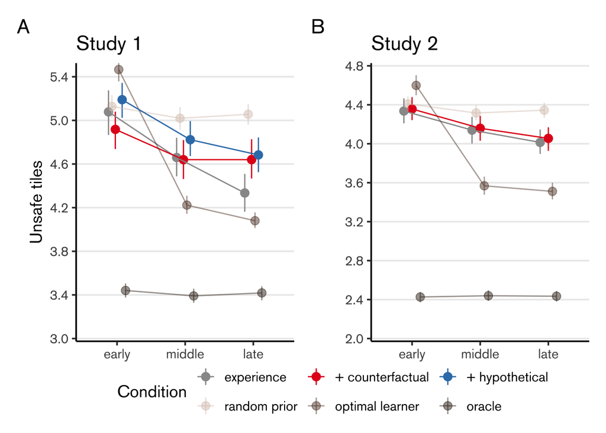

```r
day_split_labels_new <- c("split 1 of 3" = "early",
                          "split 2 of 3" = "middle",
                          "split 3 of 3" = "late")

dodge_width <- position_dodge(width = 0.3)

condition_palette <- c("experience" = "#999999",
                       "random prior" = "#DBC7BD80",
                       "experience + counterfactual" = "#e41a1c",
                       "optimal learner" = "#63453680",
                       "experience + hypothetical" = "#377eb8",
                       "oracle" = "#3D2C2280")

condition_legend_labels <- c("experience",
                             "random prior",
                             "+ counterfactual",
                             "optimal learner",
                             "+ hypothetical",
                             "oracle")

model_df_s1_ <- model_df_s1 %>%
  left_join(quicksand_df_s1 %>% select(trial_id, day, days_binned), by = "trial_id")

model_df_s2_ <- model_df_s2 %>%
  left_join(quicksand_df_s2 %>% select(trial_id, day, days_binned), by = "trial_id")


combined_s1 <- quicksand_df_s1 %>%
  filter(trial_type == "quicksand-planner") %>%
  select(condition, day, days_binned, hazard_count) %>%
  mutate(source = "human")

combined_s1_model <- model_df_s1_ %>%
  select(condition, day, days_binned, hazard_count) %>%
  mutate(source = "model")

combined_s1_all <- bind_rows(combined_s1, combined_s1_model)  %>%
  mutate(condition = factor(condition, levels = c(
    "experience",
    "random prior",
    "experience + counterfactual",
    "optimal learner",
    "experience + hypothetical",
    "oracle"
  )))

combined_s2 <- quicksand_df_s2 %>%
  filter(trial_type == "navigation") %>%
  select(condition, day, days_binned, hazard_count) %>%
  mutate(source = "human")

combined_s2_model <- model_df_s2_ %>%
  select(condition, day, days_binned, hazard_count) %>%
  mutate(source = "model")

combined_s2_all <- bind_rows(combined_s2, combined_s2_model)  %>%
  mutate(condition = factor(condition, levels = c(
    "experience",
    "random prior",
    "experience + counterfactual",
    "optimal learner",
    "experience + hypothetical",
    "oracle"
  )))

fig_s1_hyp1 <- combined_s1_all %>%
  ggplot(aes(x = days_binned, y = hazard_count, color = condition, group = condition)) +
  stat_summary(fun = mean, geom = "point", size = 3, position = dodge_width) +
  stat_summary(fun.data = mean_cl_boot, geom = "linerange", width = 0.2, position = dodge_width) +
  stat_summary(fun = mean, geom = "line", position = dodge_width) +
  scale_color_manual(values = condition_palette, labels = condition_legend_labels) +
  scale_x_discrete(labels = day_split_labels_new) +
  scale_y_continuous(breaks = seq(3.0, 5.5, 0.4), expand = expansion(mult = 0.01)) +
  coord_cartesian(ylim = c(3.0, 5.5)) +
  labs(title = "Study 1", x = "Trial order (binned)", y = "Unsafe tiles", color = "Condition") +
  guides(color = guide_legend(nrow = 2))  # allow 2 rows if legend gets crowded

fig_s2_hyp1 <- combined_s2_all %>%
  ggplot(aes(x = days_binned, y = hazard_count, color = condition, group = condition)) +
  stat_summary(fun = mean, geom = "point", size = 3, position = dodge_width) +
  stat_summary(fun.data = mean_cl_boot, geom = "linerange", width = 0.2, position = dodge_width) +
  stat_summary(fun = mean, geom = "line", position = dodge_width) +
  scale_color_manual(values = condition_palette, labels = condition_legend_labels) +
  scale_x_discrete(labels = day_split_labels_new) +
  scale_y_continuous(breaks = seq(2.0, 4.8, 0.4), expand = expansion(mult = 0.01)) +
  coord_cartesian(ylim = c(2.0, 4.8)) +
  labs(title = "Study 2", y = "", x = "Trial order (binned)") +
  guides(color = "none")


fig_combined <- fig_s1_hyp1 + fig_s2_hyp1 +
  plot_layout(ncol = 2, guides = "collect") &
  plot_annotation(tag_levels = "A") &
  theme(axis.title.x = element_blank(),
        panel.grid.major.y = element_line(),
        legend.position = "bottom",
        legend.margin = margin(-10, 0, 0, 0))

ggsave(file.path(figures_dir, 'hypothesis1.pdf'), width = 7, height = 4, useDingbats = FALSE)

fig_combined
```

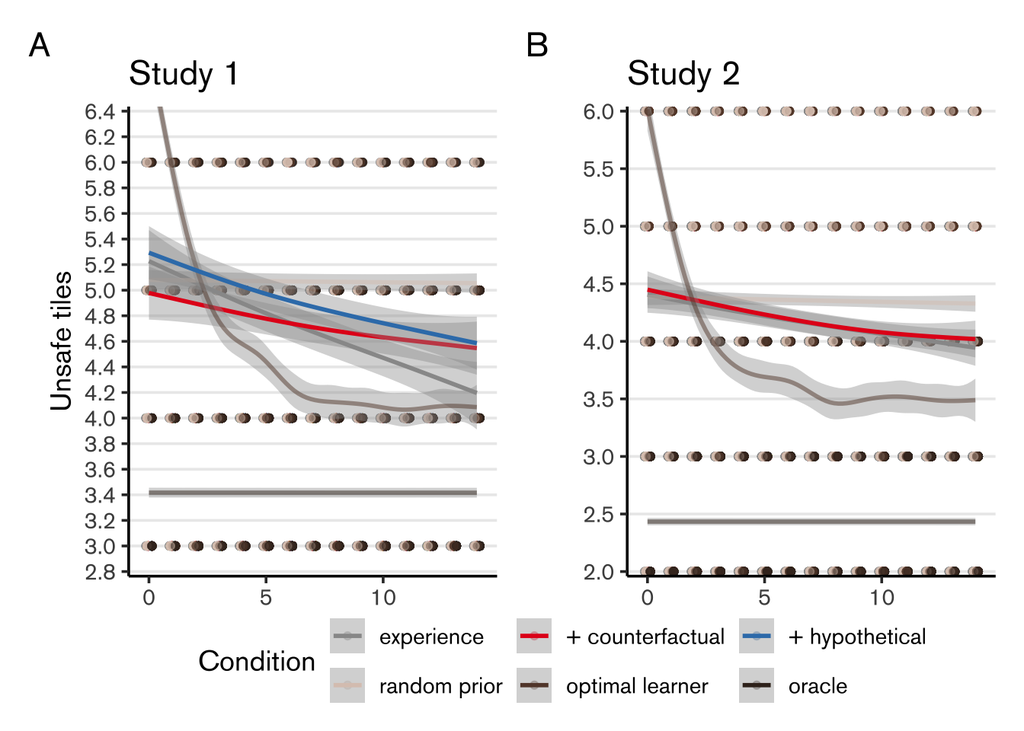

```r
fig_s1_hyp1 <- combined_s1_all %>%
  ggplot(aes(x = day, y = hazard_count, color = condition)) +
  geom_point(alpha = 0.3, position = dodge_width) +
  geom_smooth(method = "gam", formula = y ~ s(x, bs = "cs"), se = TRUE) +
  scale_color_manual(values = condition_palette, labels = condition_legend_labels) +
  scale_y_continuous(breaks = seq(2.8, 6.4, 0.2), expand = expansion(mult = 0.01)) +
  coord_cartesian(ylim = c(2.8, 6.4)) +
  labs(title = "Study 1", x = "Trial (day)", y = "Unsafe tiles", color = "Condition") +
  guides(color = guide_legend(nrow = 2))

fig_s2_hyp1 <- combined_s2_all %>%
  ggplot(aes(x = day, y = hazard_count, color = condition)) +
  geom_point(alpha = 0.3, position = dodge_width) +
  geom_smooth(method = "gam", formula = y ~ s(x, bs = "cs"), se = TRUE) +
  scale_color_manual(values = condition_palette, labels = condition_legend_labels) +
  scale_y_continuous(breaks = seq(2.0, 6.0, 0.5), expand = expansion(mult = 0.01)) +
  coord_cartesian(ylim = c(2.0, 6.0)) +
  labs(title = "Study 2", y = "", x = "Trial (day)") +
  guides(color = "none")

fig_combined <- fig_s1_hyp1 + fig_s2_hyp1 +
  plot_layout(ncol = 2, guides = "collect") &
  plot_annotation(tag_levels = "A") &
  theme(axis.title.x = element_blank(),
        panel.grid.major.y = element_line(),
        legend.position = "bottom",
        legend.margin = margin(-10, 0, 0, 0))

fig_combined
```

## Hypothesis 2: Exam performance

[figure not shown]

```r
# Exam Correct Tiles
fig_exam_correct <- world_df_s2 %>%
  ggplot(aes(x = condition,
             y = exam_trial_correct_tiles,
             fill = condition)) +
  stat_summary(fun = mean,
               geom = "bar",
               color = "black") +
  stat_summary(fun.data = mean_cl_boot,
               geom = "linerange",
               size = 0.7,
               width = 0.2) +
  geom_point(size = 0.1,
             shape = 21,
             color = "gray25",
             position = position_jitter(height = 0.2, width = 0.2),
             show.legend = FALSE) +
  scale_fill_manual(values = condition_palette,
                    labels = condition_legend_labels) +
  scale_x_discrete(labels = condition_labels) +
  scale_y_continuous(breaks = seq(0, 27, 5),
                     limits = c(0, 25),
                     expand = expansion(mult = 0.01)) +
  labs(title = NULL,
       x = "Condition",
       y = "Correct tiles",
       fill = "Condition") +
  guides(fill = guide_legend(nrow = 1))

# Exam Hazard Count (Rational planner unsafe tiles)
fig_exam_hazard <- world_df_s2 %>%
  ggplot(aes(x = condition,
             y = exam_trial_hazard_count,
             fill = condition)) +
  stat_summary(fun = mean,
               geom = "bar",
               color = "black") +
  stat_summary(fun.data = mean_cl_boot,
               geom = "linerange",
               size = 0.7,
               width = 0.2) +
  geom_point(size = 0.1,
             shape = 21,
             color = "gray25",
             position = position_jitter(height = 0, width = 0.2),
             show.legend = FALSE) +
  scale_fill_manual(values = condition_palette,
                    labels = condition_legend_labels) +
  scale_x_discrete(labels = condition_labels) +
  scale_y_continuous(breaks = seq(0, 8, 1),
                     expand = expansion(mult = 0.01)) +
  labs(title = NULL,
       x = "Condition",
       y = "Unsafe tiles",
       fill = "Condition") +
  guides(fill = guide_legend(nrow = 1))

# Combine both plots in one row
fig_combined <- fig_exam_correct + fig_exam_hazard +
  plot_layout(ncol = 2, guides = "collect") &
  plot_annotation(tag_levels = "A") &
  theme(axis.title.x = element_blank(),
        axis.text.x = element_blank(),
        axis.line.x = element_blank(),
        axis.ticks.x = element_blank(),
        panel.grid.major.y = element_line(),
        legend.position = "bottom",
        legend.margin = margin(-10, 0, 0, 0))

ggsave(file.path(figures_dir, 'hypothesis2.pdf'), width = 7, height = 3, useDingbats = FALSE)
fig_combined
```